# Tema I.2: Descripción de las Distribuciones con Números

Autor/a

LÿRA  
L.RodriguezAragon@uclm.es

Fecha de publicación

2 de febrero de 2026

**Estadística (Grados en Ingeniería 2025 / 2026)**

Licesio J. Rodríguez Aragón  
Escuela Ing. Industrial y Aeroespacial de Toledo  
Departamento de Matemáticas  
Universidad de Castilla-La Mancha

## Bloque I: Estadística Descriptiva

# Tema I.2: Descripción de las Distribuciones con Números [(p. 32)](https://elibro.net/es/ereader/bibliotecauclm/60046?page=74)

Casi siempre la descripción de una distribución incluye una medida de su **centro** y de su **dispersión**.

### Una medida de centro: la media

Para hallar **la media** de un conjunto de observaciones, suma sus valores y divide por el número de observaciones. Si las n observaciones son $x_1, x_2,...,x_n$, su media es
$$\bar x= \frac{x_1+x_2+\dots+x_n}{n},$$
o de forma más compacta:
$$\bar x=\frac{1}{n}\sum x_i.$$

**Ejemplo:** Actitud de los estudiantes (Ejercicio 1.27 [p.34](https://elibro.net/es/ereader/bibliotecauclm/60046?page=76)).

154, 109, 137, 115, 152, 140, 154, 178, 101,

103, 126, 126, 137, 165, 165, 129, 200, 148,

```r
SSHA<-c(154, 109, 137, 115, 152, 140, 154, 178, 101,103, 126, 126, 137, 165, 165, 129, 200, 148)
sum(SSHA)
```

```
[1] 2539
```

```r
length(SSHA)
```

```
[1] 18
```

```r
mean(SSHA)
```

```
[1] 141.0556
```

Debido a que la media no puede resistir la influencia de observaciones extremas, decimos que **la media no es una medida robusta de centro**.

### Una medida de centro: la mediana

La **mediana** M es el punto medio de una distribución, es decir, es el número tal que la mitad de las observaciones son menores y la otra mitad, mayores. Para hallar la mediana de una distribución:

- Ordena todas las observaciones de la mínima a la máxima.
- Si el número de observaciones $n$ es impar, entonces la mediana M es la observación central de la lista ordenada. Halla la posición de la mediana contando observaciones desde el comienzo de la lista.
- Si el número de observaciones $n$ es par, la mediana M es la media de las dos observaciones centrales de la lista ordenada. La posición de la mediana se halla, otra vez, contando observaciones desde el comienzo de la lista.

```r
SSHA<-c(154, 109, 137, 115, 152, 140, 154, 178, 101,103, 126, 126, 137, 165, 165, 129, 200, 148)
length(SSHA)
```

```
[1] 18
```

```r
sort(SSHA)
```

```
 [1] 101 103 109 115 126 126 129 137 137 140 148 152 154 154 165 165 178 200
```

```r
median(SSHA)
```

```
[1] 138.5
```

En el [Ejemplo 1.8](https://elibro.net/es/ereader/bibliotecauclm/60046?page=77) se repite paso a paso el cálculo de la mediana.

### Una medida de centro: La moda

La definición de la moda no aparece en el texto docente.

La **moda** es el valor que más se repite de una variable, o bien el intervalo de mayor recuento, intervalo modal. La moda puede no ser única.

```r
SSHA<-c(154, 109, 137, 115, 152, 140, 154, 178, 101,103, 126, 126, 137, 165, 165, 129, 200, 148)
table(SSHA)
```

```
SSHA
101 103 109 115 126 129 137 140 148 152 154 165 178 200
  1   1   1   1   2   1   2   1   1   1   2   2   1   1
```

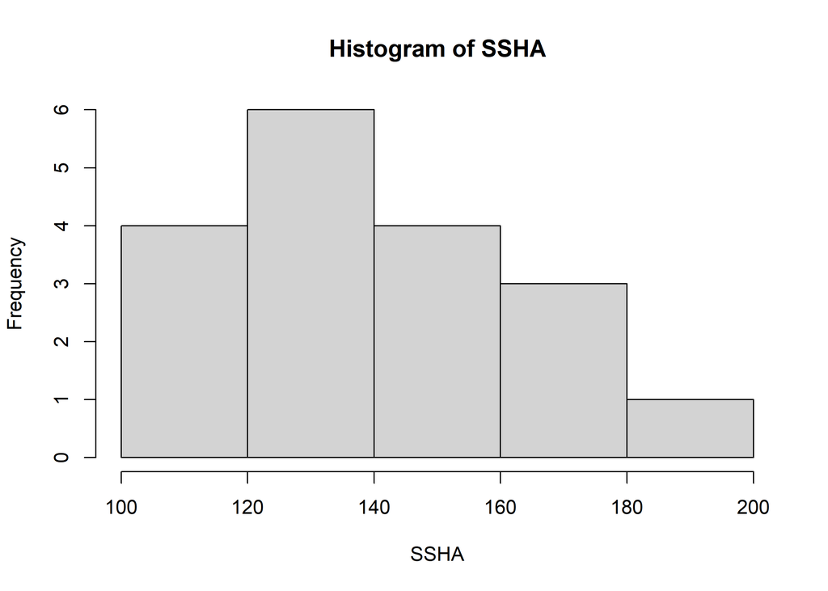

```r
hist(SSHA)
```

> Autoevaluación I.2.1: Intenta hacer el [Ejercicio 1.28](https://elibro.net/es/ereader/bibliotecauclm/60046?page=79), calcula la media, mediana y moda para el número de cesáreas llevadas a cabo por 15 médicos suizos. Recuerda que para calcular la mediana has de ordenar de menor a mayor los datos.

### Una medida de dispersión: Los cuartiles

Los **cuartiles** determinan entre qué valores se encuentra la mitad central de las observaciones.

Ordenemos las observaciones de menor a mayor:

- El primer cuartil separa el primer 25% de las observaciones. El primer cuartil es mayor que el 25% de las observaciones, $Q_1$.
- El tercer cuartil separa el primer 75% de observaciones. El tercer cuartil es mayor que el 75% de las observaciones, $Q_3$.
- El segundo cuartil es **la mediana**. El segundo cuartil es mayor que el 50% de las observaciones, $M$.

Para calcular los cuartiles:

- Ordena las observaciones en orden creciente y localiza la mediana M en la lista ordenada de observaciones, $Q_2$.
- El primer cuartil $Q_1$ es la mediana de las observaciones situadas a la izquierda de la mediana global.
- El tercer cuartil $Q_3$ es la mediana de las observaciones situadas a la derecha de la mediana global.

```r
SSHA<-c(154, 109, 137, 115, 152, 140, 154, 178, 101,103, 126, 126, 137, 165, 165, 129, 200, 148)
quantile(SSHA, 0.5)
```

```
  50%
138.5
```

```r
median(SSHA)
```

```
[1] 138.5
```

```r
sort(SSHA)
```

```
 [1] 101 103 109 115 126 126 129 137 137 140 148 152 154 154 165 165 178 200
```

```r
quantile(SSHA, 0.25)
```

```
25%
126
```

```r
quantile(SSHA, 0.75)
```

```
75%
154
```

En el [Ejemplo 1.9](https://elibro.net/es/ereader/bibliotecauclm/60046?page=81) se repite paso a paso el cálculo de los cuartiles.

### Centro y dispersión: los cinco números resumen y los diagramas de caja

Los **cinco números resumen** de un conjunto de datos consisten en la observación mínima, el primer cuartil, la mediana, el tercer cuartil y la observación máxima, escritos en orden de menor a mayor: Mínima, $Q_1$, M,$Q_3$, Máxima.

Un **diagrama de caja** muestra gráficamente los cinco números resumen.

- Los lados superior e inferior de la caja corresponden a los cuartiles.
- El segmento del interior de la caja corresponde a la mediana.
- Los extremos de los segmentos perpendiculares a los lados superior e inferior de la caja corresponden a los valores máximo y mínimo, respectivamente.

```r
summary(SSHA)
```

```
   Min. 1st Qu.  Median    Mean 3rd Qu.    Max.
  101.0   126.0   138.5   141.1   154.0   200.0
```

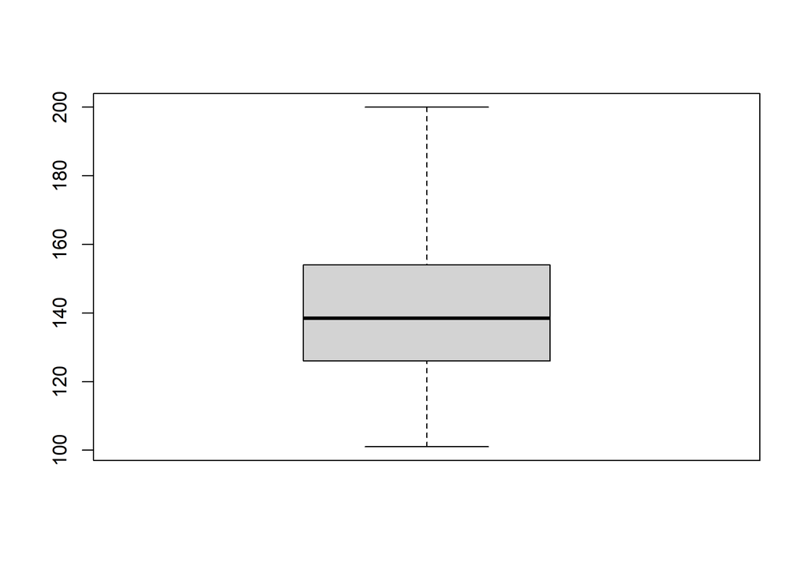

```r
boxplot(SSHA, range=0)
```

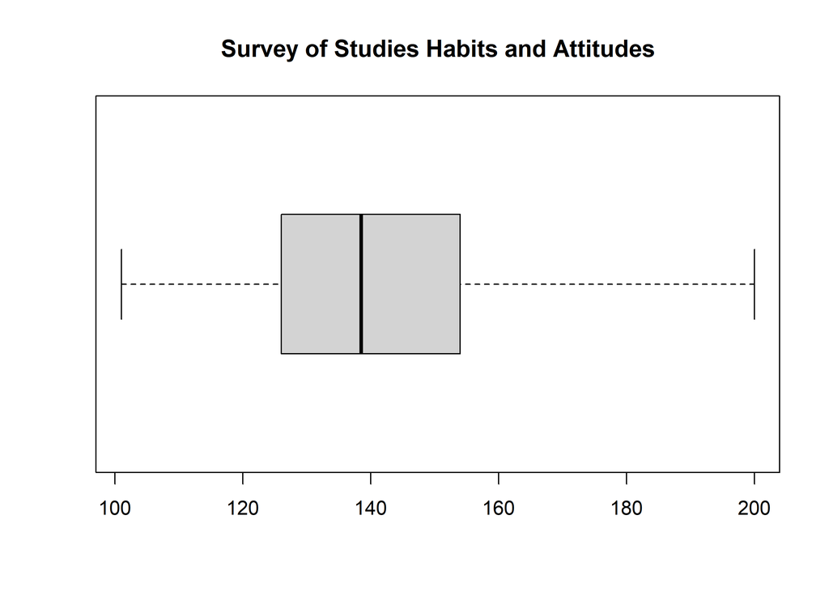

```r
boxplot(SSHA, range=0, horizontal=TRUE, main="Survey of Studies Habits and Attitudes")
```

> Autoevaluación I.2.2: Intenta hacer los ejercicios 1.31, 1.32 y 1.33 de la [pp. 42-43](https://elibro.net/es/ereader/bibliotecauclm/60046?page=84) del texto docente.

> Actualiza los datos `edades` con los años que tenían al inicio de su mandato los últimos presidentes: W. Bush, Obama, Trump(2017), Biden y Trump(2025), y vuelve a realizar los resúmenes.

### Una medida de dispersión: la varianza y la desviación típica

La **desviación típica** mide la dispersión de las observaciones respecto a la media.

La **varianza** $s^2$ de un conjunto de observaciones es la suma de los cuadrados de las desviaciones de las observaciones respecto a su media dividido por $n-1$. Algebraicamente la varianza de $n$ observaciones $x_1,x_2,...,x_n$ es
$$s^2=\frac{(x_1-\bar x)^2+(x_2-\bar x)^2+\dots+(x_n-\bar x)^2}{n-1},$$
o, de forma más simple,
$$s^2=\frac{1}{n-1}\sum (x_i-\bar x)^2.$$

La **desviación típica** es la raíz cuadrada positiva de la varianza $s^2$:
$$s=\sqrt{\frac{1}{n-1}\sum (x_i-\bar x)^2}$$

Fíjate en que para calcular la varianza $s^2$ dividimos el sumatorio por el número de observaciones menos uno, es decir, por $n-1$, en vez de $n$. La razón es que la suma de las desviaciones $x_i-\bar x$ es siempre cero, la última desviación se puede hallar cuando se conocen las otras $n-1$. Solamente $n-1$ de las desviaciones al cuadrado pueden variar libremente. Esta es la razón por la que dividimos por $n-1$. Al número $n-1$ se le denomina **grados de libertad** de la varianza o de la desviación típica.

Muchas calculadoras y paquetes estadísticos ofrecen la posibilidad de dividir por $n$ o por $n-1$. Asegúrate de dividir por $n-1$.

```r
SSHA<-c(154, 109, 137, 115, 152, 140, 154, 178, 101,103, 126, 126, 137, 165, 165, 129, 200, 148)
mean(SSHA)
```

```
[1] 141.0556
```

```r
SSHA_media2<-(SSHA-mean(SSHA))^2
SSHA_media2
```

```
 [1]  167.558642 1027.558642   16.447531  678.891975  119.780864    1.114198
 [7]  167.558642 1364.891975 1604.447531 1448.225309  226.669753  226.669753
[13]   16.447531  573.336420  573.336420  145.336420 3474.447531   48.225309
```

```r
sum(SSHA_media2)/(length(SSHA)-1)
```

```
[1] 698.8791
```

```r
var(SSHA)
```

```
[1] 698.8791
```

```r
sqrt(var(SSHA))
```

```
[1] 26.43632
```

```r
sd(SSHA)
```

```
[1] 26.43632
```

> Autoevaluación I.2.3: Realiza el ejercicio [1.36](https://elibro.net/es/ereader/bibliotecauclm/60046?page=90) utilizando el modo estadístico de tu calculadora. Si no sabes usarlo busca en el manual de tu calculadora donde hay ejemplos para calcular la media y la desviación típica. Si no tienes el manual de tu calculadora búscalo en google, lo podrás descargar el pdf.

Para describir una distribución asimétrica o una distribución con observaciones atípicas muy claras, es mejor utilizar los cinco números resumen. Utiliza $\bar x$ y $s$ sólo en el caso de distribuciones razonablemente simétricas que no presenten observaciones atípicas.

> Practica calculando medias, varianzas y desviaciones típicas con la ayuda de tu calculadora y su modo estadístico.

> Autoevaluación I.2.4: Lee detenidamente el [Resumen 1.3](https://elibro.net/es/ereader/bibliotecauclm/60046?page=91), hace un repaso de todos los conceptos vistos hasta ahora. Los Ejercicios de la [Sección 1.3](https://elibro.net/es/ereader/bibliotecauclm/60046?page=92) están ahora a tu alcance, intenta hacerlos, ante cualquier duda: PREGUNTA.

> RECUERDA: Puedes comprobar las soluciones en la [p. 796](https://elibro.net/es/ereader/bibliotecauclm/60046?page=838).